# By way of introduction…

# Anatomy of `aes()`

```r
# NOT run
ggplot(data = , aes(x = , y = , color = , linetype = , shape = , size = ))
```

These four aesthetic parameters (`color`, `linetype`, `shape`, `size`) can be used to show variation in *kind* (categories) and variation in *degree* (numeric).

Parameters passed into `aes` should be *variables* in your dataset.

Parameters passed to `geom_xxx` outside of `aes` should *not* be related to your dataset – they apply to the whole figure.

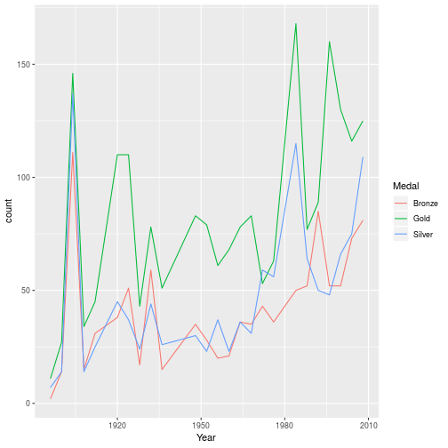

```r
ggplot(data = usa_all_medals, aes(x = Year, y = count)) +
            geom_line(aes(color = Medal))
```

Note what happens when we specify the color parameter outside of the aesthetic operator. `ggplot2` views these specifications as invalid graphical parameters.

```r
ggplot(data = usa_all_medals, aes(x = Year, y = count)) +
            geom_point(color = Medal)
```

```
## Error in layer(data = data, mapping = mapping, stat = stat, geom = GeomPoint, : object 'Medal' not found
```

```r
ggplot(data = usa_all_medals, aes(x = Year, y = count)) +
            geom_point(color = "Medal")
```

```
## Error in grDevices::col2rgb(colour, TRUE): invalid color name 'Medal'
```

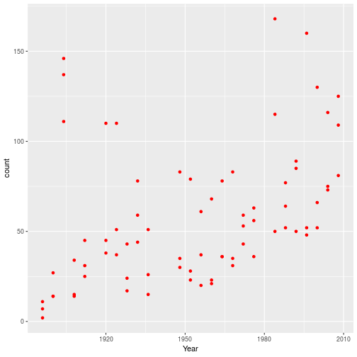

```r
ggplot(data = usa_all_medals, aes(x = Year, y = count)) +
            geom_point(color = "red")
```

# Using aesthetics to highlight features

Differences in kind

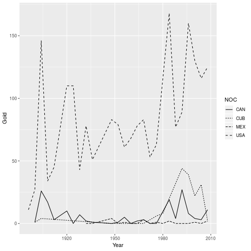

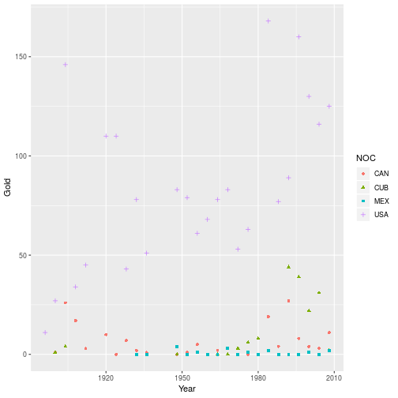

```r
ggplot(data = northern_hem, aes(x = Year, y = Gold)) +
            geom_line(aes(linetype = NOC))
ggplot(data = northern_hem, aes(x = Year, y = Gold)) +
            geom_point(aes(shape = NOC, color = NOC))
```

Differences in degree

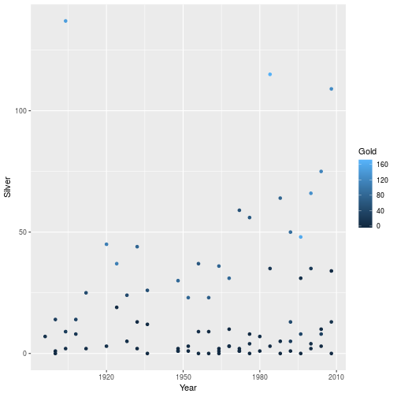

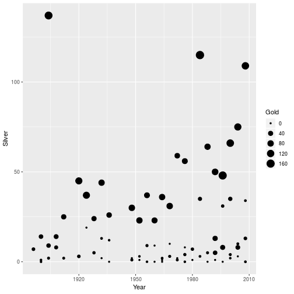

```r
ggplot(data = northern_hem, aes(x = Year, y = Silver)) +
            geom_point(aes(color = Gold))
ggplot(data = northern_hem, aes(x = Year, y = Silver)) +
            geom_point(aes(size = Gold))
```

Multiple non-coordinate aesthetics (differences in kind using color, degree using point size)

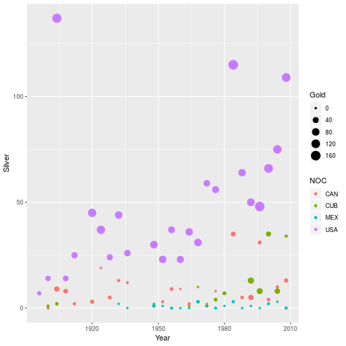

```r
ggplot(data = northern_hem, aes(x = Year, y = Silver)) +
            geom_point(aes(size = Gold, color = NOC))
```

# Changing options in ggplot2

`ggplot` handles options in additional layers.

### Labels

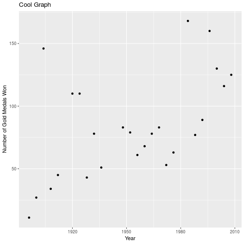

```r
ggplot(data = usa_gold_medals, aes(x = Year, y = count)) + geom_point() +
  xlab(label = "Year") +
  ylab(label = "Number of Gold Medals Won") +
  ggtitle(label = "Cool Graph") # ggplot2
```

### Axis and point scales

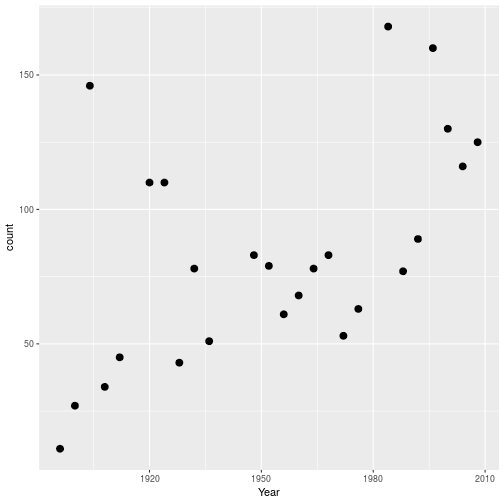

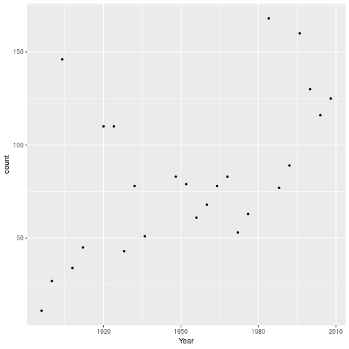

```r
ggplot(data = usa_gold_medals, aes(x = Year, y = count)) +
            geom_point() # ggplot2
ggplot(data = usa_gold_medals, aes(x = Year, y = count)) +
            geom_point(size=3) # ggplot2
ggplot(data = usa_gold_medals, aes(x = Year, y = count)) +
            geom_point(size=1) # ggplot2
```

[output not shown]

### Colors

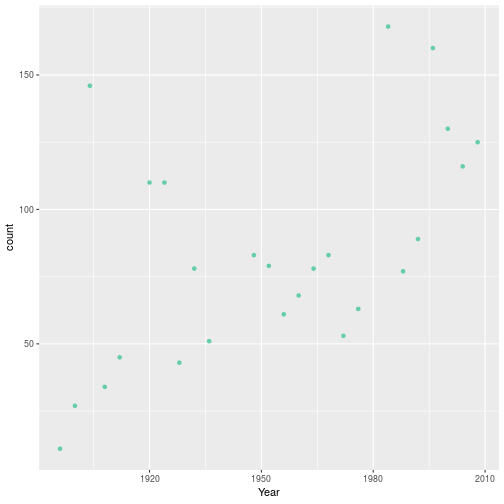

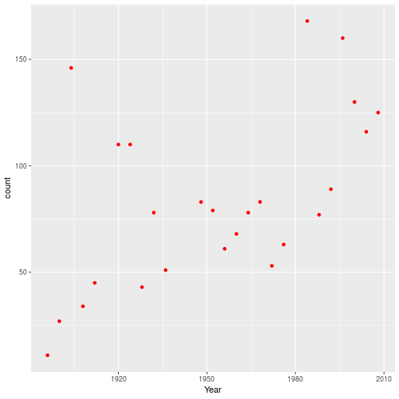

```r
ggplot(data = usa_gold_medals, aes(x = Year, y = count)) +
            geom_point(color = colors()[11]) # ggplot2
ggplot(data = usa_gold_medals, aes(x = Year, y = count)) +
            geom_point(color = "red") # ggplot2
```

### Point Styles and Widths

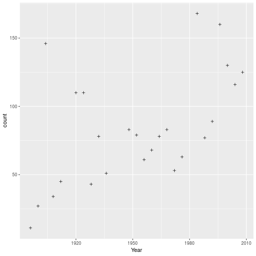

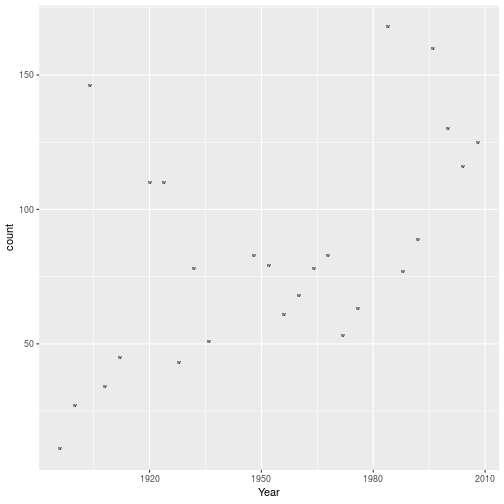

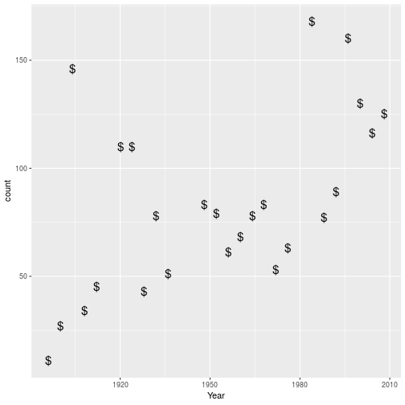

```r
ggplot(data = usa_gold_medals, aes(x = Year, y = count)) +
            geom_point(shape = 3) # ggplot2
ggplot(data = usa_gold_medals, aes(x = Year, y = count)) +
            geom_point(shape = "w") # ggplot2
ggplot(data = usa_gold_medals, aes(x = Year, y = count)) +
            geom_point(shape = "$", size=5) # ggplot2
```

### Line Styles and Widths

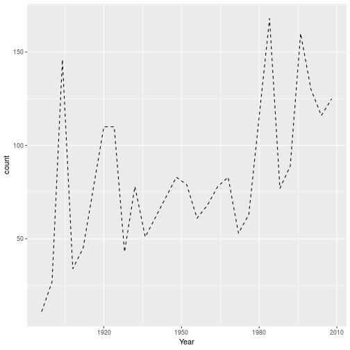

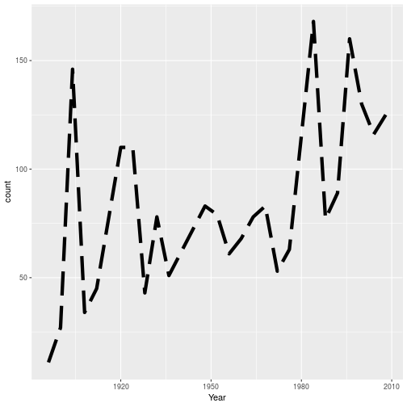

```r
ggplot(data = usa_gold_medals, aes(x = Year, y = count)) +
            geom_line(linetype = 1) # ggplot2
ggplot(data = usa_gold_medals, aes(x = Year, y = count)) +
            geom_line(linetype = 2) # ggplot2
ggplot(data = usa_gold_medals, aes(x = Year, y = count)) +
            geom_line(linetype = 5, size = 2) # ggplot2
```

[output not shown]

# Fitted lines and curves with `ggplot2`

```r
ggplot(data = usa_gold_medals, aes(x = Year, y = count)) + geom_point()
```

[output not shown]

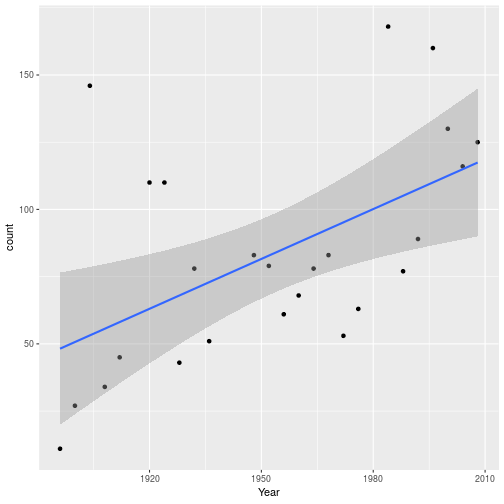

```r
# Add linear model (lm) smoother
ggplot(data = usa_gold_medals, aes(x = Year, y = count)) + geom_point() +
  geom_smooth(method = "lm")
```

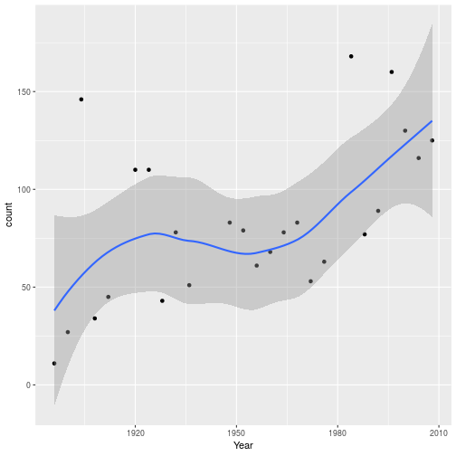

```r
# Add local linear model (loess) smoother, span of 0.75 (more smoothed)
ggplot(data = usa_gold_medals, aes(x = Year, y = count)) + geom_point() +
  geom_smooth(method = "loess", span = .75)
```

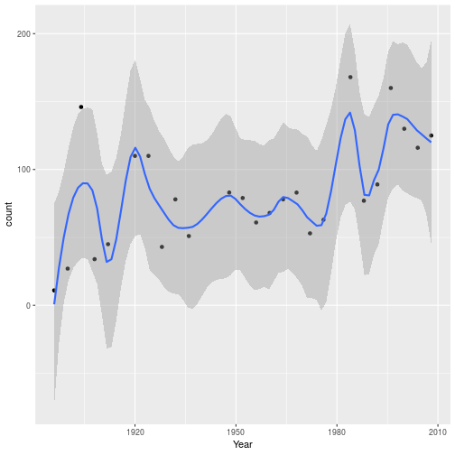

```r
# Add local linear model (loess) smoother, span of 0.25 (less smoothed)
ggplot(data = usa_gold_medals, aes(x = Year, y = count)) + geom_point() +
  geom_smooth(method = "loess", span = .25)
```

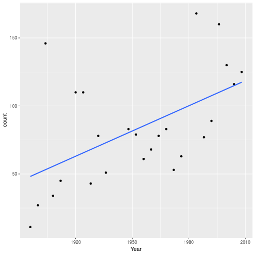

```r
# Add linear model (lm) smoother, no standard error shading
ggplot(data = usa_gold_medals, aes(x = Year, y = count)) + geom_point() +
  geom_smooth(method = "lm", se = FALSE)
```

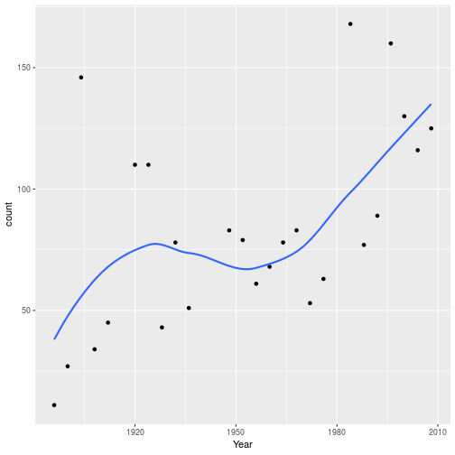

```r
# Add local linear model (loess) smoother, no standard error shading
ggplot(data = usa_gold_medals, aes(x = Year, y = count)) + geom_point() +
  geom_smooth(method = "loess", se = FALSE)
```

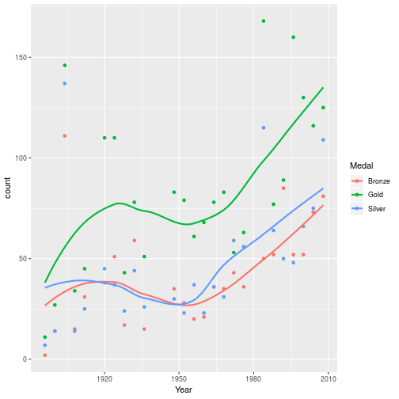

```r
# Add a local linear (loess) smoother for each medal, no standard error shading
ggplot(data = usa_all_medals, aes(x = Year, y = count)) +
  geom_point(aes(color = Medal)) +
  geom_smooth(aes(color = Medal), method = "loess", se = FALSE)
```

# Combining Multiple Plots

- `ggplot2` graphs can be combined using the *`grid.arrange()`* function in the **`gridExtra`** package

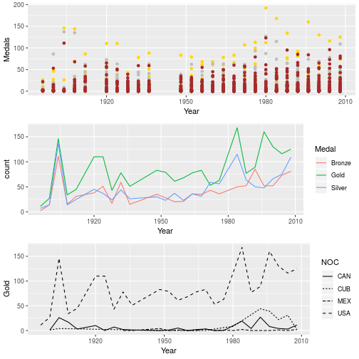

```r
# Initialize gridExtra library
library(gridExtra)

# Create 3 plots to combine in a table
plot1 <- ggplot(data = medal_counts_wide, aes(x = Year, y = Gold)) +
  geom_point(color = "gold") +
  geom_point(aes(x = Year, y = Silver), color = "gray") +
  geom_point(aes(x = Year, y = Bronze), color = "brown") +
  ylab("Medals")
plot2 <- ggplot(data = usa_all_medals, aes(x = Year, y = count)) +
      geom_line(aes(color = Medal))
plot3 <- ggplot(data = northern_hem, aes(x = Year, y = Gold)) +
      geom_line(aes(linetype = NOC))


# Call grid.arrange
grid.arrange(plot1, plot2, plot3, nrow=3, ncol = 1)
```

# `patchwork`: Combining Multiple `ggplot2` plots

- The `patchwork` package may be used to combine multiple `ggplot2` plots using a small set of operators similar to the pipe.
- This requires less syntax than using `gridExtra` and allows complex arrangements to be built nearly effortlessly.

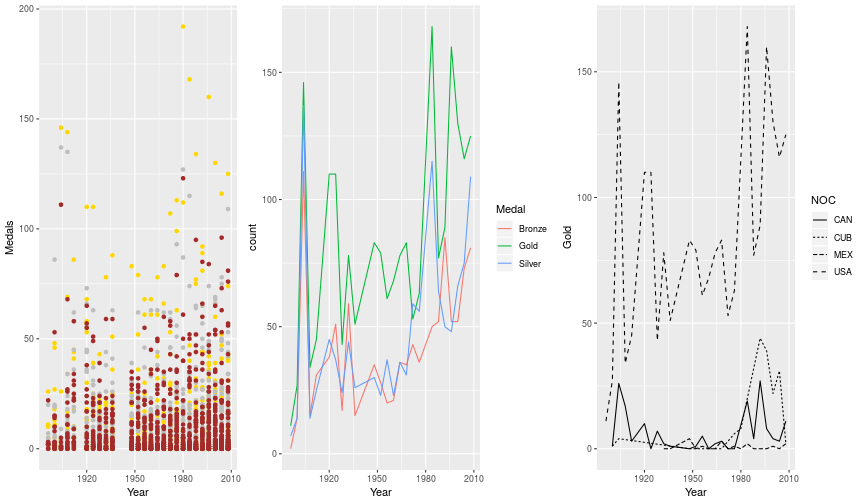

```r
# Install and initialize patchwork library
#devtools::install_github("thomasp85/patchwork")
library(patchwork)

# Create 3 plots to combine in a table
plot1 <- ggplot(data = medal_counts_wide, aes(x = Year, y = Gold)) +
  geom_point(color = "gold") +
  geom_point(aes(x = Year, y = Silver), color = "gray") +
  geom_point(aes(x = Year, y = Bronze), color = "brown") +
  ylab("Medals")
plot2 <- ggplot(data = usa_all_medals, aes(x = Year, y = count)) +
      geom_line(aes(color = Medal))
plot3 <- ggplot(data = northern_hem, aes(x = Year, y = Gold)) +
      geom_line(aes(linetype = NOC))


# use the patchwork operators
# stack plots horizontally
plot1 + plot2 + plot3
```

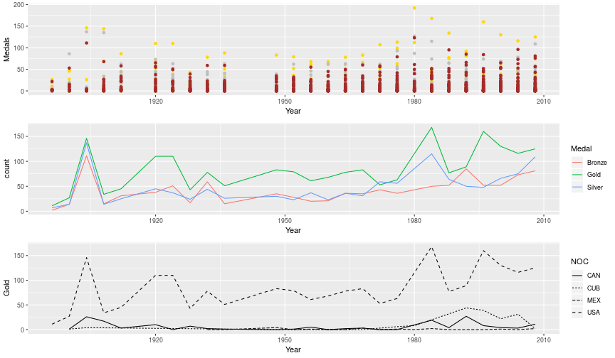

```r
# stack plots vertically
plot1 / plot2 / plot3
```

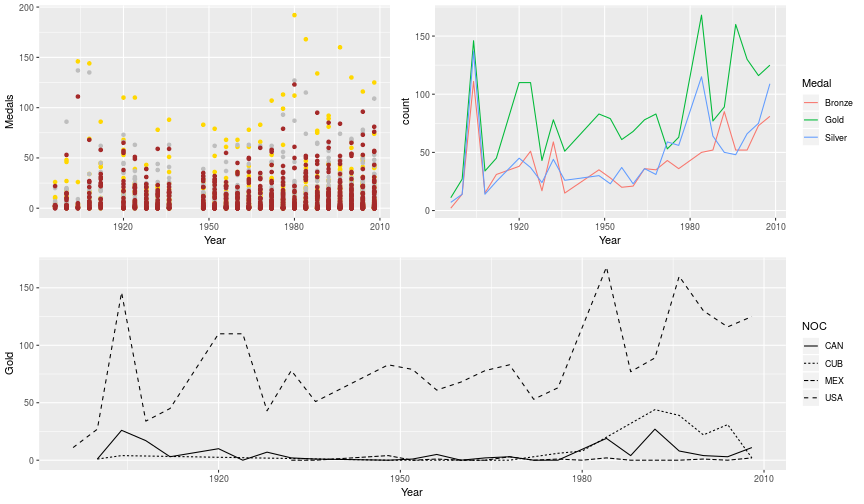

```r
# side-by-side plots with third plot below
(plot1 | plot2) / plot3
```

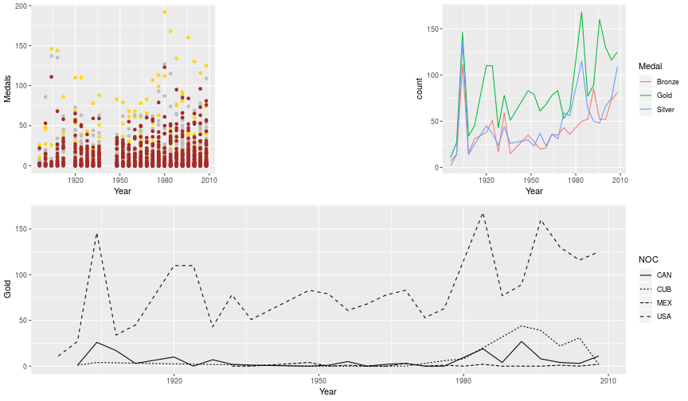

```r
# side-by-side plots with a space in between, and a third plot below
(plot1 | plot_spacer() | plot2) / plot3
```

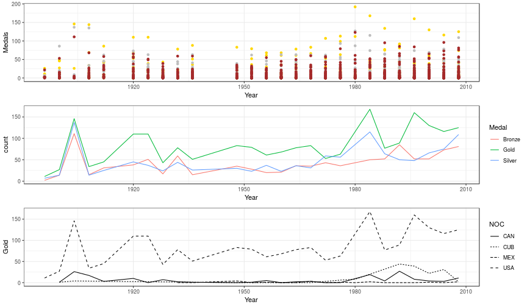

```r
# stack plots vertically and alter with a single "gg_theme"
(plot1 / plot2 / plot3) & theme_bw()
```

Feel free to explore more at https://github.com/thomasp85/patchwork.

# Exporting

Two basic image types:

### **Raster/Bitmap** (.png, .jpeg)

Every pixel of a plot contains its own separate coding; not so great if you want to resize the image

```r
jpeg(filename = "example.jpg", width=, height=)
plot(x,y)
dev.off()
```

### **Vector** (.pdf, .ps)

Every element of a plot is encoded with a function that gives its coding conditional on several factors; great for resizing

```r
# NOT run
pdf(file = "example.pdf", width=, height=)
plot(x,y)
dev.off()
```

### Exporting with `ggplot`

```r
# NOT run

# Assume we saved our plot is an object called example.plot

ggsave(filename = "example.pdf", plot = example.plot, scale = , width = ,
       height = )
```

# Breakout

These questions ask you to work with the gapminder dataset.

### Basics

1) Plot a histogram of life expectancy.

2) Plot the life expectancy against gdpPercap.

3) Clean up your scatterplot with a title and axis labels. Output it as a PDF and see if you'd be comfortable with including it in a report/paper.

4) Make a boxplot of life expectancy conditional on year.

### Using the ideas

5) Create a trellis plot of life expectancy by gdpPercap scatterplots, one subplot per year. Use a 3x4 layout of panels in the plot.

6) Plot life expectancy versus gdpPercap. Now plot so that different continents are in different colors. Use `scale_x_continuous()` to set the x-axis limits to be in the range from 100 to 50000.

7) Figure out how to use the log-scale for gdpPercap, without manually calculating the log values.

### Advanced

8) Create a “trellis” plot where, for a given year, each panel uses a) hollow circles to plot lifeExp as a function of log(gdpPercap), and b) a red loess smoother without standard errors to plot the trend. Turn off the grey background. Figure out how to use partially-transparent points to reduce the effect of the overplotting of points.